# SC-IAT-example

Ottavia M. Epifania

2022-02-15

```r
library(implicitMeasures)
```

This vignette illustrates how to use the `implicitMeasures` package for computing the SC-IAT *D* score. The illustration is based on the data set included in the package (i.e., `raw_data`).

### First thing first: Import and explore data

The labels that contains the specification `sc_` in the`blockcode` variable identify the SC-IAT blocks.

```r
data("raw_data")
# explore the dataframe
str(raw_data)
```

```
#> 'data.frame':    84726 obs. of  6 variables:
#>  $ Participant: int  4 4 4 4 4 4 4 4 4 4 ...
#>  $ latency    : int  2592 628 808 783 2059 1114 608 663 771 676 ...
#>  $ correct    : int  1 1 1 1 1 1 1 1 1 1 ...
#>  $ trialcode  : Factor w/ 32 levels "age","alert",..: 31 5 3 20 3 20 5 3 20 3 ...
#>  $ blockcode  : Factor w/ 13 levels "demo","practice.iat.Milkbad",..: 4 4 4 4 4 4 4 4 4 4 ...
#>  $ response   : Factor w/ 46 levels "","0","1","19",..: 43 43 43 43 43 43 43 43 43 43 ...
```

```r
# explore the levels of the blockcode variable to identify the SC-IAT blocks
levels(raw_data$blockcode)
```

```
#>  [1] "demo"                      "practice.iat.Milkbad"
#>  [3] "practice.iat.Milkgood"     "practice.sc_dark.Darkbad"
#>  [5] "practice.sc_dark.Darkgood" "practice.sc_milk.Milkbad"
#>  [7] "practice.sc_milk.Milkgood" "test.iat.Milkbad"
#>  [9] "test.iat.Milkgood"         "test.sc_dark.Darkbad"
#> [11] "test.sc_dark.Darkgood"     "test.sc_milk.Milkbad"
#> [13] "test.sc_milk.Milkgood"
```

`raw_data` contains data from two different SC-IATs, one for the implicit assessment of the positive/negative evaluation of Milk chocolate (`sc_milk`), and one for the implicit assessment of the positive/negative evaluation of Dark chocolate (`sc_dark`).

Once the SC-IATs blocks have been identified, it is possible to clean the data for computing the *D* score. Function `clean_sciat` allows for cleaning the data set of either just one SC-IAT or to clean the data sets of two SC-IATs concurrently. The labels identifying the test blocks must be specified as a character vector via argument `block_sciat_1` and argument `block_sciat_2` (use the `block_sciat_2` argument only if there is a second SC-IAT). The labels identifying the demographic information (if any) must be passed to the `trial_demo` argument, after specifying the column of the data set containing the labels of the demographic information (argument `demo_id`).

**DON’T USE THE `trial_eliminate` ARGUMENT TO ELIMINATE TRIALS EXCEEDING THE RESPONSE TIME WINDOW (rtw).**

The labels for identifying the responses beyond the rtw (that have to be eliminated) must be included in the variable identified by the`trial_id` label, but they have to be specified via the `non_response` argument in the `compute_sciat()` function to actually be deleted.

```r
data("raw_data")
sciat_data <- clean_sciat(raw_data, sbj_id = "Participant",
                         block_id = "blockcode",
                         latency_id = "latency",
                         accuracy_id = "correct",
                         block_sciat_1 = c("test.sc_dark.Darkbad",
                                           "test.sc_dark.Darkgood"),
                         block_sciat_2 = c("test.sc_milk.Milkbad",
                                           "test.sc_milk.Milkgood"),
                         trial_id  = "trialcode",
                         trial_eliminate = c("reminder",
                                             "reminder1"),
                         demo_id = "blockcode",
                         trial_demo = "demo")
```

Since two SC-IATs and demographic data were specified, `clean_sciat()` results in a list of 3 elements:

```r
str(sciat_data) # structure of the resulting List
```

```
#> List of 3
#>  $ sciat1:Classes 'sciat_clean' and 'data.frame':    23328 obs. of  5 variables:
#>   ..$ participant: int [1:23328] 4 4 4 4 4 4 4 4 4 4 ...
#>   ..$ block      : chr [1:23328] "test.sc_dark.Darkbad" "test.sc_dark.Darkbad" "test.sc_dark.Darkbad" "test.sc_dark.Darkbad" ...
#>   ..$ trial      : Factor w/ 32 levels "age","alert",..: 5 3 5 3 20 3 5 20 5 5 ...
#>   ..$ correct    : int [1:23328] 1 1 1 1 1 1 1 1 1 1 ...
#>   ..$ latency    : int [1:23328] 461 1495 639 573 671 643 714 1190 625 517 ...
#>  $ sciat2:Classes 'sciat_clean' and 'data.frame':    23328 obs. of  5 variables:
#>   ..$ participant: int [1:23328] 4 4 4 4 4 4 4 4 4 4 ...
#>   ..$ block      : chr [1:23328] "test.sc_milk.Milkbad" "test.sc_milk.Milkbad" "test.sc_milk.Milkbad" "test.sc_milk.Milkbad" ...
#>   ..$ trial      : Factor w/ 32 levels "age","alert",..: 3 23 3 3 3 23 23 23 20 20 ...
#>   ..$ correct    : int [1:23328] 1 1 1 1 1 1 1 1 1 1 ...
#>   ..$ latency    : int [1:23328] 653 990 594 550 818 591 570 620 661 623 ...
#>  $ demo  :'data.frame':  3726 obs. of  6 variables:
#>   ..$ participant: int [1:3726] 4 4 4 4 4 4 4 4 4 4 ...
#>   ..$ latency    : int [1:3726] 53047 53047 53047 53047 21554 21554 11266 11266 11266 11266 ...
#>   ..$ correct    : int [1:3726] 1 1 1 1 1 1 1 1 1 1 ...
#>   ..$ trialcode  : Factor w/ 32 levels "age","alert",..: 19 1 21 8 22 4 10 11 12 13 ...
#>   ..$ blockcode  : Factor w/ 13 levels "demo","practice.iat.Milkbad",..: 1 1 1 1 1 1 1 1 1 1 ...
#>   ..$ response   : Factor w/ 46 levels "","0","1","19",..: 33 15 41 34 16 20 1 1 1 1 ...
```

The first two elements (`sciat1` and `sciat2`) are two `data.frame` with class `sciat_clean`. They contain the data of the SC-IATs specified in the `block_sciat1` and `block_sciat2` arguments of the `clean_sciat()` function, respectively. The third element (`demo`) is a `data.frame` that contains the demographic information as specified in the `trial_demo` argument of function `clean_sciat()`.

Each element of the resulting list can be stored in a separate object.

```r
sciat1 <- sciat_data[[1]] # extract first SC-IAT data
sciat2 <- sciat_data[[2]] # extract second SC-IAT data
demo_data <- sciat_data[[3]] # extract demographic information

head(sciat1)
```

```
#>    participant                block     trial correct latency
#> 23           4 test.sc_dark.Darkbad  darkleft       1     461
#> 24           4 test.sc_dark.Darkbad   badleft       1    1495
#> 25           4 test.sc_dark.Darkbad  darkleft       1     639
#> 26           4 test.sc_dark.Darkbad   badleft       1     573
#> 27           4 test.sc_dark.Darkbad goodright       1     671
#> 28           4 test.sc_dark.Darkbad   badleft       1     643
```

```r
head(demo_data)
```

```
#>       participant latency correct trialcode blockcode response
#> 81001           4   53047       1    gender      demo     male
#> 81002           4   53047       1       age      demo       29
#> 81003           4   53047       1       job      demo     stud
#> 81004           4   53047       1       edu      demo       MD
#> 81005           4   21554       1 milk_eval      demo        3
#> 81006           4   21554       1 dark_eval      demo        4
```

### Compute the SC-IAT D-score

Once the SC-IAT(s) data have been cleaned with the `clean_sciat()` function, it is possible to compute the *D* score by using function `compute_sciat()`.

This function takes three mandatory arguments and one optional argument. The three mandatory arguments are the data set with class `sciat_clean`, and the labels identifying the two critical associative conditions (arguments `mappingA` and `mappingB`). If the SC-IAT administration included a rtw, the label identifying the trials exceeding the threshold must be specified via the (optional) argument `non_response`.

```r
# Compute the D-score for the first SC-IAT
 d_sciat1 <- compute_sciat(sciat1,
                  mappingA = "test.sc_dark.Darkbad",
                  mappingB = "test.sc_dark.Darkgood",
                  non_response = "alert")

# dataframe containing the SC-IAT D-score of the of the first SC-IAT
str(d_sciat1)
```

```
#> Classes 'dsciat' and 'data.frame':   162 obs. of  15 variables:
#>  $ participant      : chr  "100" "101" "102" "103" ...
#>  $ n_trial          : int  144 144 144 144 144 144 144 144 144 144 ...
#>  $ no_response      : int  0 0 0 0 0 0 0 0 0 0 ...
#>  $ nslow10000       : num  0 0 0 0 0 0 0 0 0 0 ...
#>  $ nfast400         : num  0.03 0.05 0.01 0.01 0 0 0.01 0.11 0.02 0.05 ...
#>  $ nfast350         : num  0.01 0.01 0 0 0 0 0 0.01 0 0 ...
#>  $ out_accuracy     : chr  "keep" "keep" "keep" "keep" ...
#>  $ accuracy.mappingA: num  0.986 0.986 0.958 0.986 1 ...
#>  $ accuracy.mappingB: num  0.944 0.986 0.931 0.986 0.931 ...
#>  $ RT_mean.mappingA : num  626 785 627 586 885 ...
#>  $ RT_mean.mappingB : num  730 913 704 633 1056 ...
#>  $ cond_ord         : chr  "MappingB_First" "MappingB_First" "MappingB_First" "MappingB_First" ...
#>  $ legendMappingA   : chr  "test.sc_dark.Darkbad" "test.sc_dark.Darkbad" "test.sc_dark.Darkbad" "test.sc_dark.Darkbad" ...
#>  $ legendMappingB   : chr  "test.sc_dark.Darkgood" "test.sc_dark.Darkgood" "test.sc_dark.Darkgood" "test.sc_dark.Darkgood" ...
#>  $ d_sciat          : num  -0.413 -0.242 -0.393 -0.288 -0.314 ...
```

```r
# Compute D-score for the second SC-IAT
 d_sciat2 <- compute_sciat(sciat2,
                  mappingA = "test.sc_milk.Milkbad",
                  mappingB = "test.sc_milk.Milkgood",
                  non_response = "alert")

 # dataframe containing the SC-IAT D-score of the of the second SC-IAT
 head(d_sciat2)
```

```
#>   participant n_trial no_response nslow10000 nfast400 nfast350 out_accuracy
#> 1         100     144           0          0     0.02     0.01         keep
#> 2         101     144           0          0     0.02     0.00         keep
#> 3         102     144           0          0     0.02     0.00         keep
#> 4         103     144           0          0     0.00     0.00         keep
#> 5         104     144           0          0     0.00     0.00         keep
#> 6         105     144           0          0     0.03     0.01         keep
#>   accuracy.mappingA accuracy.mappingB RT_mean.mappingA RT_mean.mappingB
#> 1         0.9436620         0.9722222         695.2269         648.8692
#> 2         0.9861111         1.0000000         917.3706         699.7917
#> 3         0.9583333         0.9166667         757.4988         784.3854
#> 4         0.9861111         0.9722222         640.5077         607.7566
#> 5         1.0000000         0.9861111         849.7500         928.0496
#> 6         1.0000000         1.0000000         540.3099         614.8611
#>         cond_ord       legendMappingA        legendMappingB     d_sciat
#> 1 MappingB_First test.sc_milk.Milkbad test.sc_milk.Milkgood  0.16120777
#> 2 MappingB_First test.sc_milk.Milkbad test.sc_milk.Milkgood  0.58453600
#> 3 MappingB_First test.sc_milk.Milkbad test.sc_milk.Milkgood -0.08226841
#> 4 MappingB_First test.sc_milk.Milkbad test.sc_milk.Milkgood  0.24119095
#> 5 MappingB_First test.sc_milk.Milkbad test.sc_milk.Milkgood -0.26484892
#> 6 MappingB_First test.sc_milk.Milkbad test.sc_milk.Milkgood -0.50147795
```

The `compute_sciat()` function results in a `data.frame` with class `dsciat` containing a number of rows equal to the number of participants, their *D* score, and a bunch of useful information on their performance (see the documentation for the `compute_sciat()` function for further information). The `descript_d()`, `d_point()`, and `d_density()` functions require the object resulting from the `compute_sciat()` function to work.

### Descriptive statistics

The descriptive statistics of the *D* score and of the response times in the two critical conditions can be easily obtained with the `descript_d()` function:

```r
descript_d(d_sciat1) # Data frame containing SC-IAT D-scores
```

```
#>               Mean     SD    Min     Max
#> D-Sciat      -0.04   0.32  -0.91    0.78
#> RT.MappingA 700.53 125.94 459.56 1299.09
#> RT.MappingB 710.23 125.28 462.28 1218.77
```

By specifying `latex = TRUE`, the `descript_d()` function prints the results in LaTeX code

```r
descript_d(d_sciat2, # Data frame containing IAT D-scores
           latex = TRUE) # obtain the code for latex tables
```

```
#> % latex table generated in R 4.1.2 by xtable 1.8-4 package
#> % Tue Feb 15 18:40:47 2022
#> \begin{table}[ht]
#> \centering
#> \begin{tabular}{rrrrr}
#>   \hline
#>  & Mean & SD & Min & Max \\
#>   \hline
#> D-Sciat & 0.16 & 0.34 & -0.95 & 1.20 \\
#>   RT.MappingA & 729.20 & 146.02 & 448.56 & 1686.09 \\
#>   RT.MappingB & 681.52 & 109.97 & 485.15 & 1166.36 \\
#>    \hline
#> \end{tabular}
#> \end{table}
```

### Plotting the results

The `implicitMeasures` package comes with several functions for obtaining nice and clear representations of the results at both individual respondent and sample levels. Additionally, it includes functions for plotting SC-IAT *D* scores resulting from two different SC-IATs.

#### Individual respondent plot

The `d_point()` function plots the SC-IAT *D* score for each respondent.

```r
 d_point(d_sciat1) # Data frame containing SC-IAT D-scores
```

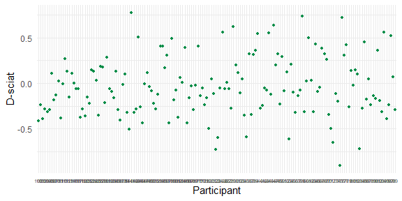

Default use of function d_point()

In case of large sample size the label identifying each respondent is not easy to read, and it can be eliminated by setting `x_values = FALSE`. Respondents can be arranged by increasing or decreasing *D* scores by setting argument `order_sbj` equal to `"D-increasing"` or `"D-decreasing"`, respectively. Descriptive statistics (i.e., $M_{\text{D-score}}\pm 2sd$) can be added by setting `include_stats = TRUE`. Finally, the color of the points can be changed by using the `col_point` argument.

```r
d_point(d_sciat1, # dataframe containing SC-IAT D-scores
       order_sbj = "D-increasing", # change respondents' order
       x_values = FALSE,  # remove respondents' labels
       include_stats = TRUE, # include descriptive statistics
       col_point = "aquamarine3") # change points color
```

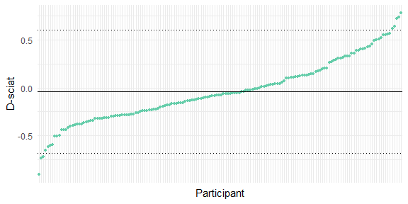

Function d_point() with settings change

#### Sample plot

The `d_density()` function plots the distribution of the SC-IAT *D* scores. It provides different options for choosing the most appropriate representation.

```r
d_density(d_sciat1) # Data frame containing SC-IAT D-scores
```

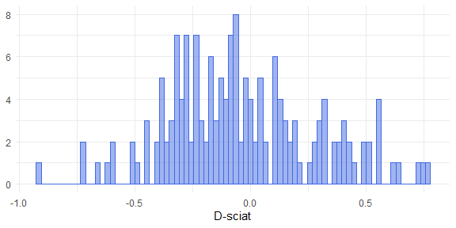

Default use of function d_density() function

The number of bins can be changed with the `n_bin` argument. The `graph` argument can be used for changing the graphical representation of the data. It is possible to choose an histogram representation (`graph = "histogram"`, default), a representation of the density distribution (`graph = "density"`), or a violin plot (`graph = "violin"`). The `col_fill` argument can be used to change the color of the points representing each respondent’s score in the violin plot. Finally, also descriptive statistics (i.e., $M_{\text{D-score}} \pm 2sd$) can be added to the graph by setting argument `include_stats = TRUE`.

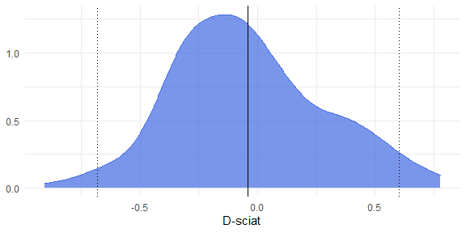

d_density() function with settings change

```r
d_density(d_sciat1, # dataframe containing IAT Dscores
        graph = "density", # change graphical representation
        include_stats = TRUE) # include descriptive statistics
```

#### Multiple SC-IATs

The `multi_dsciat()` function plots the distributions of the *D* scores obtained from two different SC-IATs. This function takes only two mandatory arguments, which are the data frames containing the results of each SC-IAT obtained by using function `compute_sciat()`. The type of graphical representation can be changed by using `graph`, which is set to `"density"` by default. Default representation also contains the lines that indicate the mean of each distribution. These lines can be taken out of the graph by setting `dens_mean = FALSE`.

```r
multi_dsciat(d_sciat1, # dataframe containing the results of the first SC-IAT
             d_sciat2) # dataframe containing the results of the second SC-IAT
```

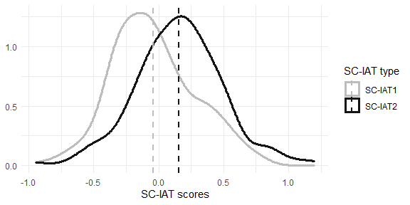

Default results representation of function multi_dsciat()

The `graph` argument can be set equal to `"violin"` (violin plots of the SC-IATs *D* scores) or `"point"` (point representation of both SC-IATs *D* scores). The labels identifying each SC-IAT can be set with the `label_sc1` and `label_sc2` arguments (defaults are `"SC-IAT 1"` and `"SC-IAT 2"`). The values labels of the $x$-axis can be removed by setting `x-values = FALSE` (suggested in case of large sample size). The `gcolors` argument can be used to change the colors of each SC-IAT (default is `"dark"`). Other colors options are `"greens"`, `"blues"`, and `"pink"`.

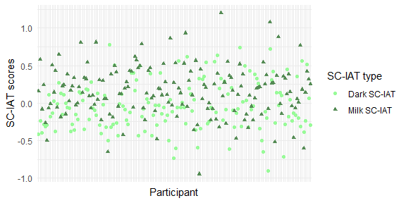

Results representation of function multi_dsciat() with settings change

```r
multi_dsciat(d_sciat1, # dataframe containing the results of the first SC-IAT
             d_sciat2, # dataframe containing the results of the second SC-IAT
             graph = "point", # change graph type
       x_values = FALSE, # take out x values
       gcolors = "greens", # change color
       label_sc1 = "Dark SC-IAT",  # change label first SC-IAT
       label_sc2 = "Milk SC-IAT") # change label second SC-IAT
```